# Gaussian Processes (or should I say compilations?)

Ciarán McInerney

2023-06-23

#### Requisites

```r
# Load packages.
library(tidyverse)
library(RobustGaSP)
library(gridExtra)
library(latex2exp)
library(DiceKriging)
# Instantiate shared variables.
sd <- 2
n <- 1000
# Set seed.
set.seed(1)
# Set reusable plot formatting.
plotformatting <-
  theme(panel.grid.major = element_blank(),
        panel.grid.minor = element_blank(),
        axis.title.x = element_blank(),
        axis.title.y = element_blank(),
        axis.text.x = element_blank(),
        axis.text.y = element_blank(),
        strip.text = element_blank()
        )
```

## TL;DR

Say you come across some random variables. Grab a handful, combine them, and calculate their multivariate distribution. If you get a multivariate Gaussian distribution for every random handful you grab, then you have a Gaussian process. This multivariate Gaussian distribution is informed by random variables, just like how a univariate distribution is informed by random observations. Distributions of random variables are useful because, just like we can know something about unobserved observations from a known univariate distribution, we can know something about unobserved random variables from a known distribution of a Gaussian process. Also, we can know something about their variance.  
The relationship between the component random variables is described by the covariance function. A typical covariance matrix describes how two random variables relate by summarising how possible observations from two random variables vary around their respective means. Very specific, and standard. In contrast, a covariance function describes how the possible observations of different random variables relate, and you can pick and choose the relationship.

## Why?

So, what is the motivation behind Gaussian processes?  
Once upon a time, a South African by the name of Danie G. Krige was trying to estimate the distribution of gold deposits across an entire region when all he had to work with were observations of gold from a disparate sample of boreholes. His work – summarised in [his 1951 publication](https://journals.co.za/doi/epdf/10.10520/AJA0038223X_4792) entitled “A statistical approach to some basic mine valuation problems on the Witwatersrand” – was read by the French mathematician Georges Matheron who developed the ideas and created the field of geostatistics. Matheron developed a method that provides the best-linear-unbiased-prediction of interpolated values, which he called Kriging after Danie G. Krige and his inspiring work.

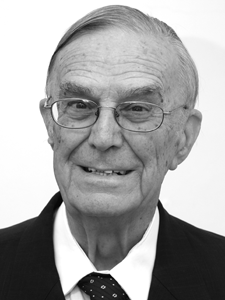

[figure not shown]

(Left) Danie Krige, namesake of ‘Kriging’. (Right) Georges Matheron, who developed Danie Krige’s work.

```r
par(mar = c(4, 4, .1, .1))
knitr::include_graphics("GaussianProcess_explainer_files/figure-gfm/danie_krige.jpeg")
knitr::include_graphics("GaussianProcess_explainer_files/figure-gfm/georges_matheron.jpg")
```

Kriging uses Gaussian processes to interpolate values based on some prior knowledge of how observations covary. For geostatisticians like Krige and Matheron, it’s about interpolating the likely quantity of mineral deposits distributed throughout a landscape. Generally, kriging can be used to interpolate the value of one random variable by having some (but not necessarily complete) knowledge of how it covaries with another random variable (in addition to assuming that the unobserved random variables are merely unobserved components of the multivariate distribution rather than some other posse of variables).

### Processes or compilations?

The development of Kriging is a great example of why I think Gaussian compilations is a more accurate description of Gaussian processes. All that is required is that we have a set of random variables, but we don’t need those random variables to be sequential realisations of the same underlying phenomenon. The only reason they are called Gaussian processes is because sometimes we want to believe that each random variable we grab is representing a repeated observation of some latent variable. In other words, as we proceed, we take further observations through time. But Danie Krige’s work on mining is more concerned with compiling random variable across space rather than time - compiling observations into a map rather than stitching them into a sequence.

## Seriously, what?

Obviously, in the previous sections, I left out some important details, but it was all in aid of you getting the gist.  
First of all, when I said “*Grab a handful* [of random variables] *, combine them*”, I actually needed you to linearly combine them, i.e. sum them after multiplying each by some constant. Gaussian processes don’t work otherwise, which is one of their limitations. Secondly, I didn’t make clear an essential distinction between distributions of random observations and distributions of random variables. To explain, I’d like to evoke Bob Ross and to paint (i.e. plot) some mountains.

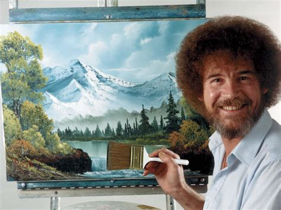

A delightful Bob Ross with one of his paintings.

```r
knitr::include_graphics("GaussianProcess_explainer_files/figure-gfm/bobrossmountain.jpg")
```

### Mountain plotter

Let’s say you are shown a mountain asked me to paint it. I’m feeling entrepreneurial and decide to automate the process because I think more people will want this kind of painting in the future. Obviously, my automated mountain painter – which I’ve called mountain plotter – will need some variability so that I don’t counterfeit my marvelous work!  
For my first attempt, I ask to know the height of the mountain and how spread out it is. My friend doesn’t know but gives a rough estimate of both. To plot my first attempt, I use the density of a univariate Gaussian distribution. These are characterised by a mean and a variance. The mean will specify the location of the peak, horizontally, and the variance will inform the sloppiness of the sides. The height at any given point on the mountain is given by the ‘density’ – i.e. the proportion of observations we would expect at the given horizontal location; highest in the middle at the mean location, lower as move away from the mean location.

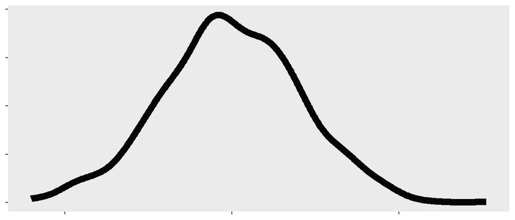

```r
myMean <- 5
df_univariate <-
  data.frame(
    var_val = rnorm(n, myMean, sd),
    var_name = as.factor(1)
  )
(p_univar <-
    ggplot(df_univariate) +
    stat_density(aes(x = var_val, linetype = var_name),
                 position = "identity", geom = "line",
                 color = 'grey2', linewidth = 3,
                 show.legend = F) +
    plotformatting
)
```

Importantly, this mountain that I have plotted was generated by specifying a distribution for ‘mountain heights’ and sampling observations from it (making it look smooth was just my artistic license). Another way of saying this is that 1) I’m trying to plot the entire mountain by 2) sampling from a single distribution. This first attempt looks pretty good but there isn’t much variability between paintings when I run the script multiple times. Also, the mountain doesn’t have a natural shape.

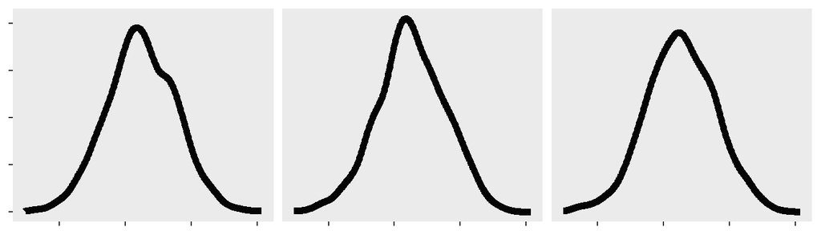

```r
# Specifiy the mean
myMean <- 5
# Create the plot data.
df_univariate_multiple <-
  data.frame(
    var_val = numeric(),
    var_name = factor()
  )
for (iter in 1:3)
{
  this_var <-
    data.frame(
      var_val = rnorm(n, myMean, sd),
      var_name = as.factor(iter)
    )
  df_univariate_multiple <- dplyr::bind_rows(df_univariate_multiple, this_var)
}
# Plot.
(p_univar_multiple <-
    ggplot(df_univariate_multiple) +
    stat_density(aes(x = var_val),
                 position = "identity", geom = "line",
                 color = 'grey2', linewidth = 2,
                 show.legend = F) +
    facet_wrap(~var_name) +
    plotformatting
)
```

For my second attempt, I ask to know the height at a handful of points along the mountain and to know how certain my friend is of these height estimates. Obviously, knowing all the points would be ideal but that is too much to ask of my friend and having that information would limit my mountain plotter to only plot that one mountain.  
When I knew the peak height of the mountain and its variance in heights, I was able to infer the heights at all points on the mountain. But how can I infer the heights at all points on the mountain when all I have are my friend’s guesses of heights at only a few points along the mountain? Thankfully, Gaussian processes / compilations can help us do just that, and produce mountain ranges like what I show below. (*Specifically, I make use of a Gaussian process emulator, which you can learn more about in [my other explainer](https://github.com/ciaranmci/SoMaS)*)

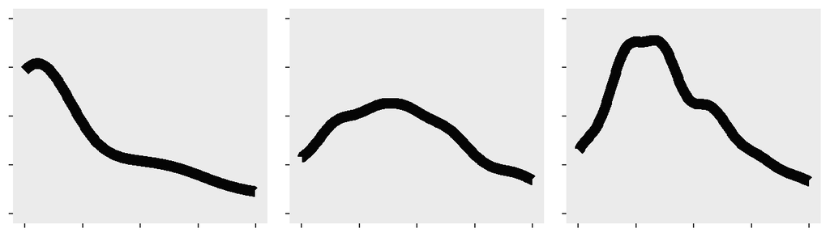

```r
# Extract the plotting data from the plot.
data_p_univar <-
  ggplot2::ggplot_build(p_univar)$data[[1]]
for (i_plot in 1:3)
{
  # Create the plot data.
  GP_data <-
    data_p_univar %>%
      dplyr::select(x, y) %>%
      dplyr::sample_n(45) %>%
      dplyr::arrange(x)
  # Fit a Gaussian process model, with power exponential kernel.
  model <- RobustGaSP::rgasp(design = GP_data$x,
                             response = GP_data$y,
                             kernel_type = 'pow_exp',
                             alpha = 3)
  testing_input = as.matrix(sort(seq(min(GP_data)*1.1, max(GP_data)*1.1, 1/50)))
  # Prepare plot data.
  df_GP <-
    data.frame(
        testing_input = testing_input,
        model_prediction = predict(model, testing_input)
      )
  # Plot
  assign(
    paste0("p_GP", i_plot),
    df_GP %>%
      ggplot(aes(x = testing_input,
                 y = model_prediction.mean)) +
      geom_line(color = "grey2", linewidth = 3,
                show.legend = F) +
      xlim(2, 10) + ylim(0, 0.2) +
      plotformatting
  )


}
# Final plotting.
gridExtra::grid.arrange(p_GP1, p_GP2, p_GP3,
                        ncol = 3)
```

So, how did I go from a single, isolated peak to an interacting mountain range?

## How?

As I said earlier, my first attempt at plotting a mountain used a single, univariate distribution. The plot was the result of asking *How high can I expect each point on the mountain to be if I assume the height of any given point on the mountain is expected to be* $\mu$ *with some uncertainty* $\sigma^2$*?* By taking this approach, I inferred the unobserved heights at various points on the mountain by knowing only the overall expected height (i.e. the mean) and how heights at all point relate to it (i.e. variance).  
In contrast, my second attempt at plotting a mountain used multiple univariate distributions that were neatly described by a single, multivariate distribution - i.e. a Gaussian process / compilation. The plot was the result of asking a different question: *How high can I expect each point on the mountain to be if I assume the height of each point has its own expected value* $\mu_{point}$ *with its own uncertainty* $\sigma_{point}^2$ *, and I only observe a handful of these?*  
Crucially, I didn’t specify the expected heights and uncertainties for each point on the mountain. Instead, I used only a handful of expected heights while also specifying how each height on the mountain relates to another. By doing so, I inferred unobserved expected heights and their uncertainty rather than merely inferring unobserved heights from a single random variable.  
This can be visualised with something as simple as box plots.

### More, more, more

I assume you have seen box plots before. It is an example of a distributional plot, just like barcode plots and [violin plots](https://chartio.com/learn/charts/violin-plot-complete-guide/). Let’s start really small and plot the distributions of three categorical variables. The plot below shows the distributions as familiar box plots, but also as (what I call) barcode plots.

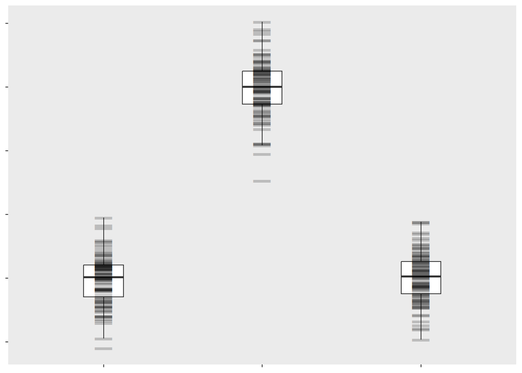

```r
# Specify the heights of the barcode plots.
heights <- c(5, 20, 5)
# Create the plot data.
df_barcode <-
  data.frame(
    val = numeric(),
    group = factor()
  )
for (iter in 1:3)
{
  this_var <-
    data.frame(
      val = rnorm(n / 10, heights[iter], sd),
      group = as.factor(iter)
    )
  df_barcode <- dplyr::bind_rows(df_barcode, this_var)
}
(df_barcode %>%
  ggplot(aes(x = group, y = val)) +
  geom_boxplot(
    width = 0.25,
    outlier.shape = NA) +
  geom_point(
    shape = 95,
    size = 10,
    alpha = 0.2) +
    plotformatting
  )
```

We are used to seeing these kinds of visualisations. They tell us that there are multiple values (shown vertically) associated with multiple categories (shown horizontally).  
Now, let’s increase the number of categories. I’ll drop the boxplots and only show the barcode plots.

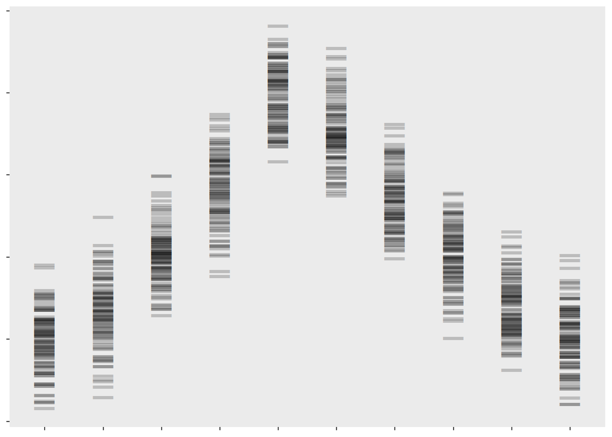

```r
# Specify the heights of the barcode plots.
heights <- c(5, 7, 10, 14, 20, 18, 14, 10, 7, 5)
# Create the plot data.
df_barcode <-
  data.frame(
    val = numeric(),
    group = factor()
  )
for (iter in 1:10)
{
  this_var <-
    data.frame(
      val = rnorm(n / 10, heights[iter], sd),
      group = as.factor(iter)
    )
  df_barcode <- dplyr::bind_rows(df_barcode, this_var)
}
(df_barcode %>%
  ggplot(aes(x = group, y = val)) +
  geom_point(
    shape = 95,
    size = 10,
    alpha = 0.2) +
    plotformatting
  )
```

Again, no problems here; it’s all very familiar. The variable being represented by the categories on the horizontal axis appears to have a lot of categories and each category has a lot of vertical values.  
Now, let’s push this to the ridiculous end of the spectrum. Fancy 80 categories?

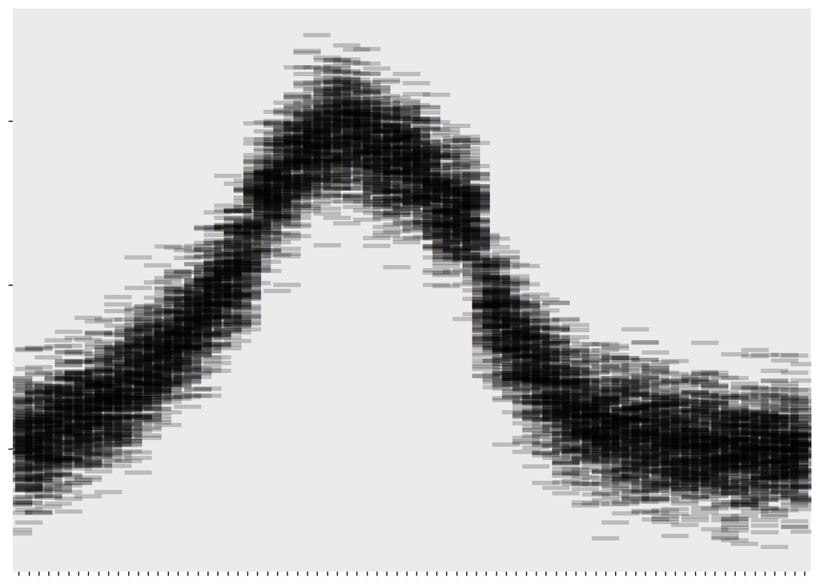

```r
# Set number of categories.
cats <- 80
# Specify the heights of the barcode plots.
heights <-
  ggplot2::ggplot_build(p_univar)$data[[1]] %>%
  dplyr::select(x, y) %>%
  dplyr::sample_n(cats) %>%
  arrange(x, y) %>%
  dplyr::select(y) %>%
  as.matrix()*100
# Create the plot data.
df_barcode <-
  data.frame(
    val = numeric(),
    group = factor()
  )
for (iter in 1:cats)
{
  this_var <-
    data.frame(
      val = rnorm(n / 10, heights[iter], sd),
      group = as.factor(iter)
    )
  df_barcode <- dplyr::bind_rows(df_barcode, this_var)
}
(df_barcode %>%
  ggplot(aes(x = group, y = val)) +
  geom_point(
    shape = 95,
    size = 10,
    alpha = 0.2) +
    plotformatting
  )
```

It’s all blurring together - like a blurry view of a mountain through the haze. Now you see that I wasn’t plotting multiple values for any arbitrary categories; I was plotting multiple height values for locations along a mountain range.  
Looking at a plot like the one immediately above, you might start to think that the variable on the horizontal axis has so many values that it might be wise to model it as a continuous variable. Voila! You now have a way to conceptualise Gaussian processes / compilations: infinitely many distributional plots. In fact, I created the previous plot by sampling density values from our univariate Gaussian distribution, using each density value (i.e. height) as the mean for a Gaussian distribution, then plotting them with barcode plots.  
(*Side note: I choose to visualise the plot using many discrete horizontal values rather than a continuous one because I think it better illustrates the approaching-infinite behaviour of what Gaussian processes / compilations do*.)  
If you look at the plots below from left to right, you can see how I generated the Gaussian-process mountain ranges from earlier (the right-most one):

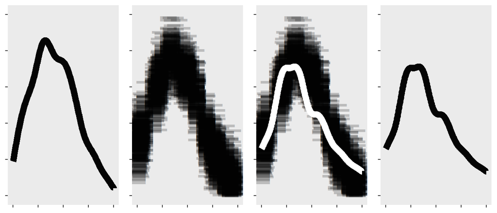

```r
## Sample some height data.
df_sample<-
  data_p_univar %>%
  dplyr::select(x, y) %>%
  dplyr::sample_n(100) %>%
  dplyr::arrange(x)
# Create the plot data.
df_blurry <-
  data.frame(
    val = numeric(),
    group = numeric()
  )
for (iter in 1:100)
{
  this_var <-
    data.frame(
      val = rnorm(n / 10, df_sample$y[iter]*100, sd),
      group = df_sample$x[iter]
    )
  df_blurry <- dplyr::bind_rows(df_blurry, this_var)
}
# Make component plot `df_blurry`.
p_blurry <-
    ggplot() +
    geom_point(
      data = df_blurry,
      aes(x = group, y = val),
      shape = 95,
      size = 10,
      alpha = 0.2) +
    plotformatting
# Make component plot `overlay`.
p_overlay <-
  p_blurry +
  geom_line(data = df_GP,
            aes(x = testing_input,
                y = model_prediction.mean*100),
            color = "white", linewidth = 3,
            show.legend = F) +
  plotformatting
# Final plotting.
gridExtra::grid.arrange(p_univar + xlim(2, 10) + ylim(0, 0.25),
                        p_blurry + xlim(2, 10) + ylim(0, 25),
                        p_overlay + xlim(2, 10) + ylim(0, 25),
                        p_GP3 + xlim(2, 10) + ylim(0, 0.25),
                        ncol = 4)
```

In the four-plot visualisation above, I did the following:

1. I started with a mountain generated using my univariate approach. Each data point represents a height. With your mathematics hat on, you can think of this as a plot of mountain height as a function of horizontal location.
2. I considered each point along the mountain to be the mean of its own Gaussian distribution of height at that horizontal location. This produced the blurry view, like a mountain through the haze.
3. I fit a Gaussian process emulator to the blurry mountain range data, which, essentially, tried to ‘learn’ the set of all functions that could pass through the data points. I then predicted the mean function’s values along the width of the mountain range, which is the white line in the third image. (Note: The white line might not match up with the centre of each barcode plot because the barcode plots are only a sample of observations from each distribution.)
4. Finally, I plotted only the series of the mean function’s values outputted from the emulator.

As I mentioned earlier, if you want to learn more about Gaussian processs emulators, check out [my other explainer](https://github.com/ciaranmci/SoMaS).

### Covariance functions

In the previous visualisation, I showed the four steps I took to produce a smooth mountain range. I chose the mean predicted values from the distributions, which produced something quite smooth. But there are actually infinitely-many curves / functions / mountain ranges that would satisfy the distributions of heights at each point on the mountain range. For example, I might not care at all about smoothness and opt to model the mountain range as a discontinuous function of randomly sampled heights at each point:

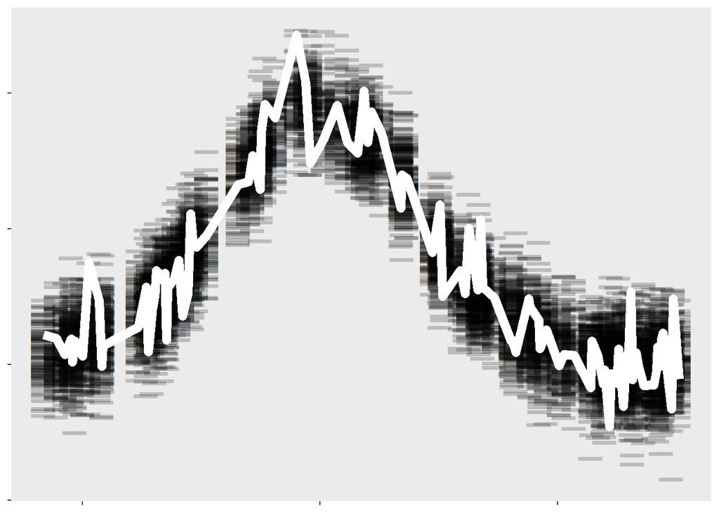

```r
# Randomly sample from each random variable.
df_jaggedy <-
  df_blurry %>%
  group_by(group) %>%
  dplyr::sample_n(1)
# Plot.
(p_jaggedy <-
  p_blurry +
  geom_line(data = df_jaggedy,
            aes(x = group,
                y = val),
            color = "white", linewidth = 3,
            show.legend = F) +
  plotformatting)
```

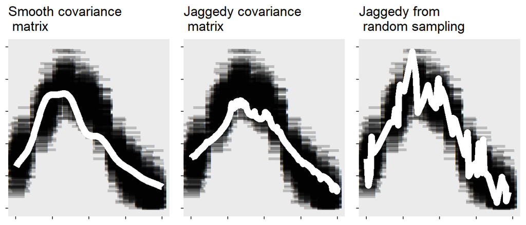

```r
# Fit a Gaussian process model using the same sample data and covariance matrix
# as the one to which I will be comparing, but change the length-scale parameter.
model <- RobustGaSP::rgasp(design = GP_data$x,
                           response = GP_data$y,
                           kernel_type = 'pow_exp',
                           alpha = 0.08)
testing_input = as.matrix(sort(seq(min(GP_data)*1.1, max(GP_data)*1.1, 1/50)))
# Prepare plot data.
df_GP_jaggedy <-
  data.frame(
      testing_input = testing_input,
      model_prediction = predict(model, testing_input)
    )
# Make component plot for `jagged_overlay`.
p_jagged_overlay <-
  p_blurry +
  geom_line(data = df_GP_jaggedy,
            aes(x = testing_input,
                y = model_prediction.mean*100),
            color = "white", linewidth = 3,
            show.legend = F) +
  plotformatting

# Final plotting.
gridExtra::grid.arrange(p_overlay + xlim(2, 10) + ylim(0, 25) + ggtitle('Smooth covariance\n matrix'),
                        p_jagged_overlay + xlim(2, 10) + ylim(0, 25) + ggtitle('Jaggedy covariance\n matrix'),
                        p_jaggedy + xlim(2, 10) + ylim(0, 25) + ggtitle('Jaggedy from\n random sampling'),
                        ncol = 3)
```

The jaggedy version made using a covariance matrix is notably less-jagged than the jaggedy version made using random sampling. This isn’t surprising given that enforcing any correlation between heights points will smooth things out.

### But what is a covariance function?

One way to think about it is to compare covariance functions with covariance matrices. A covariance matrix describes how two random variables relate by summarising how possible observations from two random variables vary around their respective means. Very specific, and standard. In contrast, a covariance function describes how the possible observations of different random *variables* relate, and you can pick-and-choose the relationship.  
Covariance functions are also called kernels because they perform the kernel trick, just like for support vector machines. A quick explanation of kernels goes something like this:

1. models can be used to map input values to output values.
2. representing the relationship between inputs and outputs can be as simple or as complicated as you like.
3. the complications can either be incorporated via the modelling - e.g. a big messy logistic regression or a neural network model - or via a transformation of the inputs before applying a simpler model - e.g. kernels in for support vector machines or covariance functions for Gaussian process models.

Essentially, kernel tricks like the covariance functions are an additional model that we add to our main model that relates the inputs to the outputs. There are many common covariance functions that you can check out on [the wikipedia page](https://en.wikipedia.org/wiki/Gaussian_process#Usual_covariance_functions), but you could just invent your own, if you like. For my smooth mountain range, I used an exponential covariance function that was inspired from models of [volcanic hazards](http://www2.stat.duke.edu/~berger/papers/volcano.pdf)! This covariance function happened to have a roughness parameter, $\alpha$ ,that I could tweak to smooth out the ridge lines between my mountain peaks (see [the RobustGaSP paper](https://journal.r-project.org/archive/2019/RJ-2019-011/RJ-2019-011.pdf) for details of the `RobustGaSP::rgasp()` function in R).

## Final thoughts and other resources

Gaussian processes - or as I like to call them, “compilations” - are an example of making clever use of a pattern to infer details. The pattern is multivariate Gaussian distributions and the details are the values of the component random variables that you don’t observe. This has been put to great use in Gaussian process regression. I encourage you to check out [this video](https://www.youtube.com/watch?v=UBDgSHPxVME) for a python tutorial in building a Gaussian process regression model. Hopefully, after reading this blog, you will understand what the developer is talking about. Be aware that many people say “Gaussian processes” when they are actually talking about Gaussian process regression, e.g. [Mutual Information](https://www.youtube.com/@Mutual_Information)’s beautifully-visualised [video on “Gaussian processes”](https://www.youtube.com/watch?v=UBDgSHPxVME)).  
But Gaussian processes / compilations aren’t perfect. Gaussian processes require that the multivariate Gaussian distribution arises for any linear predictor of component random variables that are Gaussian distributed. Linear predictors are handy mathematical objects but there is nothing inherently more correct or representative about them than other ways of combining random variables. Below is snippet of a slide I show my students to reveal what assumptions we make when we specify some linear-predictor models:

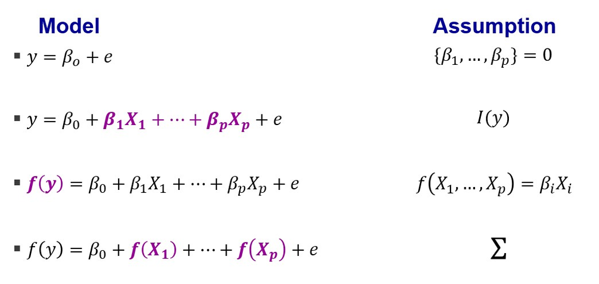

```r
knitr::include_graphics("GaussianProcess_explainer_files/figure-gfm/why_limit_to_linear_predictors.jpg")
```

As you can see, summing the random variables is only an assumption and is not set in stone. [Nardo et al.](https://www.oecd.org/sdd/42495745.pdf) would consider the outputs of linear predictors to be “*composite indicators*” and, therefore, potentially victim to issues of compensability. Perhaps multiplying the random variables would be more appropriate, particularly when the output is used for ranking. But multiplying Gaussian distributions provides a lognormal distribution rather than a multivariate Gaussian, so the theory of Gaussian processes / compilations don’t apply.  
As the legendary [Donella ‘Dana’ Meadows](https://donellameadows.org/) once said, [“*the worst assumptions…are the ones that got left out*”](https://www.youtube.com/watch?v=XL_lOoomRTA). What are we assuming about the random variables when we assume they combine in a linear predictor? What does the summation of a linear predictor mean/represent in reality?  
It seems appropriate to quote Donella Meadows again when it comes to linear predictions. In her book, [Thinking in Systems: A primer](https://donellameadows.org/systems-thinking-book-sale/), Meadows says “*You think that because you understand ‘one’ that you must therefore understand ‘two’ because one and one make two. But you forget that you must also understand ‘and’.*”

### Resources

1. For a great, interactive explainer of Gaussian processes, look no further than [Görtler, Kehlbeck, and Deussen’s blog](https://distill.pub/2019/visual-exploration-gaussian-processes/) from distill.pub publications.
2. distill.pub publications also have a blog by [Agnihotri and Batra](https://distill.pub/2020/bayesian-optimization/) on Bayesian optimization that pays homage to Krige’s initial work.